# Course Notes 5

January 12, 2016

## Parentheses

## Parentheses

If you put parentheses around an entire code statement, it will both run the code and print out the answer.

```r
my_names <- c("Reeves", "Brooke", "Cord")
my_names
```

```
## [1] "Reeves" "Brooke" "Cord"
```

```r
(my_names <- c("Reeves", "Brooke", "Cord"))
```

```
## [1] "Reeves" "Brooke" "Cord"
```

## Loops

## Loops

For *some index* in *some vector*, do *some code*.

For `i` in `1:3`, `print(i)`:

```r
for(i in 1:3){
        print(i)
}
```

```
## [1] 1
## [1] 2
## [1] 3
```

## Loops

For *some index* in *some vector*, do *some code*.

For `name` in `my_names`, `print(name)`:

```r
my_names <- c("Reeves", "Brooke", "Cord")
for(name in my_names){
        print(name)
}
```

```
## [1] "Reeves"
## [1] "Brooke"
## [1] "Cord"
```

## Loops

Often, it's convenient to use `i` loop through a vector or dataframe using indexing.

For `i` in `1:length(my_names)`, `print(my_names[i])`:

```r
my_names <- c("Reeves", "Brooke", "Cord")
for(i in 1:length(my_names)){
        print(my_names[i])
}
```

```
## [1] "Reeves"
## [1] "Brooke"
## [1] "Cord"
```

## Loops

What would this loop do?

```r
vars <- c("Time", "Shots", "Passes", "Tackles", "Saves")
for(i in 1:length(vars)){
        var_mean <- mean(worldcup[ , vars[i]])
        print(var_mean)
}
```

## Loops

```r
vars <- c("Time", "Shots", "Passes", "Tackles", "Saves")
for(i in 1:length(vars)){
        var_mean <- mean(worldcup[ , vars[i]])
        print(var_mean)
}
```

```
## [1] 208.8639
## [1] 2.304202
## [1] 84.52101
## [1] 4.191597
## [1] 0.6672269
```

## Loops

What would this loop do?

```r
vars <- c("Time", "Shots", "Passes", "Tackles", "Saves")
for(i in 1:length(vars)){
        var_mean <- mean(worldcup[ , vars[i]])
        var_mean <- round(var_mean, 1)
        out <- paste0("mean of ", vars[i], ": ", var_mean)
        print(out)
}
```

## Loops

To figure out, you can set `i <- 1` and then walk through the loop:

```r
i <- 1
(var_mean <- mean(worldcup[ , vars[i]]))
```

```
## [1] 208.8639
```

```r
(var_mean <- round(var_mean, 1))
```

```
## [1] 208.9
```

```r
(out <- paste0("mean of ", vars[i], ": ", var_mean))
```

```
## [1] "mean of Time: 208.9"
```

## Loops

```r
vars <- c("Time", "Shots", "Passes", "Tackles", "Saves")
for(i in 1:length(vars)){
        var_mean <- mean(worldcup[ , vars[i]])
        var_mean <- round(var_mean, 1)
        out <- paste0("mean of ", vars[i], ": ", var_mean)
        print(out)
}
```

```
## [1] "mean of Time: 208.9"
## [1] "mean of Shots: 2.3"
## [1] "mean of Passes: 84.5"
## [1] "mean of Tackles: 4.2"
## [1] "mean of Saves: 0.7"
```

## Loops

Often, it's convenient to create a dataset to fill up as you loop through:

```r
vars <- c("Time", "Shots", "Passes", "Tackles", "Saves")
my_df <- data.frame(variable = vars, mean = NA)
for(i in 1:nrow(my_df)){
        var_mean <- mean(worldcup[ , vars[i]])
        my_df[i , "mean"] <- round(var_mean, 1)
}
```

## Loops

```r
vars <- c("Time", "Shots", "Passes", "Tackles", "Saves")
(my_df <- data.frame(variable = vars, mean = NA))
```

```
##   variable mean
## 1     Time   NA
## 2    Shots   NA
## 3   Passes   NA
## 4  Tackles   NA
## 5    Saves   NA
```

## Loops

```r
i <- 1
(var_mean <- mean(worldcup[ , vars[i]]))
```

```
## [1] 208.8639
```

```r
my_df[i , "mean"] <- round(var_mean, 1)
my_df
```

```
##   variable  mean
## 1     Time 208.9
## 2    Shots    NA
## 3   Passes    NA
## 4  Tackles    NA
## 5    Saves    NA
```

## Loops

```r
for(i in 1:nrow(my_df)){
        var_mean <- mean(worldcup[ , vars[i]])
        my_df[i , "mean"] <- round(var_mean, 1)
}
my_df
```

```
##   variable  mean
## 1     Time 208.9
## 2    Shots   2.3
## 3   Passes  84.5
## 4  Tackles   4.2
## 5    Saves   0.7
```

## Loops

Note: This is a pretty simplistic example. There are some easier ways to have done this:

```r
summarize(worldcup, Time = mean(Time),
          Passes = mean(Passes), Tackles = mean(Tackles),
          Saves = mean(Saves)) %>%
        gather(var, mean) %>%
        mutate(mean = round(mean, 1))
```

```
##       var  mean
## 1    Time 208.9
## 2  Passes  84.5
## 3 Tackles   4.2
## 4   Saves   0.7
```

## Loops

Note: This is a pretty simplistic example. There are some easier ways to have done this:

```r
means <- apply(worldcup[ , vars], 2, mean)
(means <- round(means, 1))
```

```
##    Time   Shots  Passes Tackles   Saves
##   208.9     2.3    84.5     4.2     0.7
```

However, you can use this same looping process for much more complex tasks that you can't do as easily with `apply` or `dplyr` tools.

## Loops

Loops can be very useful for more complex repeated tasks. For example:

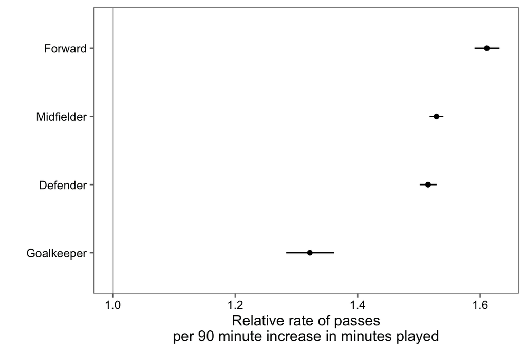

## Loops

Creating this graph requires:

- Create a subset limited to each of the four positions
- Fit a Poisson regression of Passes on Time within each subset
- Pull the regression coefficient and standard error from each model
- Use those values to calculate 95% confidence intervals
- Convert everything from log relative rate to relative rate
- Plot everything

## Loops

Create a vector with the names of all positions. Create an empty dataframe to store regression results.

```r
(positions <- unique(worldcup$Position))
```

```
## [1] Midfielder Defender   Forward    Goalkeeper
## Levels: Defender Forward Goalkeeper Midfielder
```

```r
(pos_est <- data.frame(position = positions, est = NA, se = NA))
```

```
##     position est se
## 1 Midfielder  NA NA
## 2   Defender  NA NA
## 3    Forward  NA NA
## 4 Goalkeeper  NA NA
```

## Loops

Loop through and fit a Poisson regression model for each subset of data. Save regression coefficients in the empty dataframe.

```r
for(i in 1:nrow(pos_est)){
        pos_df <- subset(worldcup, Position == positions[i])
        pos_mod <- glm(Passes ~ Time,
                       data = pos_df,
                       family = poisson(link = "log"))
        pos_coefs <- summary(pos_mod)$coefficients["Time", 1:2]
        pos_est[i, c("est", "se")] <- pos_coefs
}
pos_est[1:2, ]
```

```
##     position         est           se
## 1 Midfielder 0.004716096 4.185925e-05
## 2   Defender 0.004616260 5.192736e-05
```

## Loops

Calculate 95% confidence intervals for log relative risk values.

```r
pos_est$lower_ci <- with(pos_est, est - 1.96 * se)
pos_est$upper_ci <- with(pos_est, est + 1.96 * se)
pos_est[1:2, ]
```

```
##     position         est           se    lower_ci    upper_ci
## 1 Midfielder 0.004716096 4.185925e-05 0.004634052 0.004798140
## 2   Defender 0.004616260 5.192736e-05 0.004514483 0.004718038
```

## Loops

Calculate relative risk per 90 minute increase in minutes played.

```r
pos_est[ , c("rr_est", "rr_low", "rr_high")] <-
        exp(90 * pos_est[ , c("est", "lower_ci", "upper_ci")])
pos_est[1:2, ]
```

```
##     position         est           se    lower_ci    upper_ci   rr_est
## 1 Midfielder 0.004716096 4.185925e-05 0.004634052 0.004798140 1.528747
## 2   Defender 0.004616260 5.192736e-05 0.004514483 0.004718038 1.515073
##     rr_low  rr_high
## 1 1.517501 1.540077
## 2 1.501258 1.529015
```

## Loops

Re-level the `position` factor so the plot will be ordered from highest to lowest estimates.

```r
pos_est <- arrange(pos_est, rr_est) %>%
        mutate(position = factor(position, levels = position))
pos_est
```

```
##     position         est           se    lower_ci    upper_ci   rr_est
## 1 Goalkeeper 0.003101124 1.686543e-04 0.002770562 0.003431687 1.321941
## 2   Defender 0.004616260 5.192736e-05 0.004514483 0.004718038 1.515073
## 3 Midfielder 0.004716096 4.185925e-05 0.004634052 0.004798140 1.528747
## 4    Forward 0.005299009 7.146148e-05 0.005158945 0.005439074 1.611090
##     rr_low  rr_high
## 1 1.283192 1.361861
## 2 1.501258 1.529015
## 3 1.517501 1.540077
## 4 1.590908 1.631527
```

## Loops

Create the plot.

```r
ggplot(pos_est, aes(x = rr_low, y = position)) +
        geom_segment(aes(xend = rr_high, yend = position)) +
        geom_point(aes(x = rr_est, y = position)) +
        theme_few() +
        ylab("") +
        scale_x_continuous(paste("Relative rate of passes\nper",
                                 "90 minute increase in minutes played"),
                           limits = c(1.0, max(pos_est$rr_high))) +
        geom_vline(aes(xintercept = 1), color = "lightgray")
```

## Loops

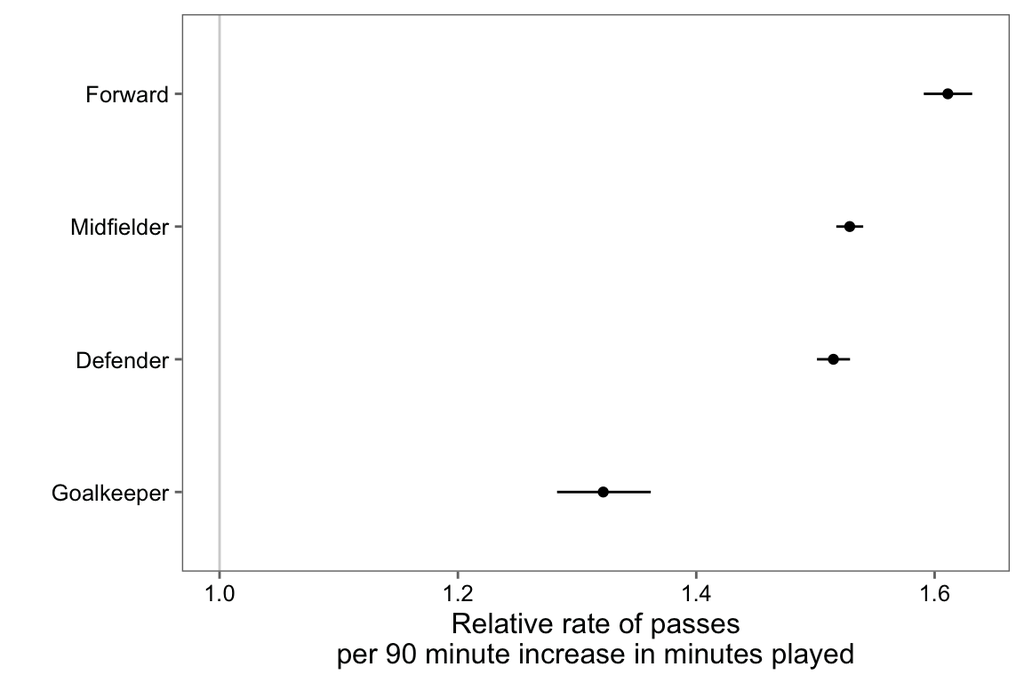

## Functions

You can write your own functions for tasks you do a lot. If you find yourself cutting and pasting a lot, convert the code to a function.

```r
add_one <- function(number){
        out <- number + 1
        return(out)
}

add_one(number = 3)
```

```
## [1] 4
```

```r
add_one(number = -1)
```

```
## [1] 0
```

## Functions

You can name a function anything you want (although try to avoid names of pre-existing functions). You then include options (including any defaults) and the code to run:

```r
## Note: this code will not run
[function name] <- function([any options and defaults]){
        [code to run]
}
```

## Functions

Example: You want to take a log relative rate estimate determined per minute and convert it to a relative rate per 90 minutes.

```r
rr_per90 <- function(log_rr){
        out <- exp(log_rr * 90)
        return(out)
}
rr_per90(pos_est$est[1])
```

```
## [1] 1.321941
```

## Functions

Example: You want to take a vector of values for a log relative rate estimate and its standard error and convert it to a pretty format of relative rate and confidence intervals per 90 minute increase in playing time:

```r
pretty_rr90 <- function(vec){
        ests <- vec[1] + c(0, -1, 1) * 1.96 * vec[2]
        ests <- round(exp(90 * ests), 2)
        out <- paste0(ests[1], " (", ests[2], ", ", ests[3], ")")
        return(out)
}
pretty_rr90(c(0.0031, 0.00017))
```

```
## [1] "1.32 (1.28, 1.36)"
```

## Functions

You can test out functions by walking through them, just like you can with loops.

```r
vec <- c(0.0031, 0.00017)
(ests <- vec[1] + c(0, -1, 1) * 1.96 * vec[2])
```

```
## [1] 0.0031000 0.0027668 0.0034332
```

```r
(ests <- round(exp(90 * ests), 2))
```

```
## [1] 1.32 1.28 1.36
```

```r
(out <- paste0(ests[1], " (", ests[2], ", ", ests[3], ")"))
```

```
## [1] "1.32 (1.28, 1.36)"
```

## Functions

You can use `apply` to apply a function you've created to many rows at a time. For example, you have log relative risk estimates and standard errors for each position in `pos_est`:

```r
pos_est[ , c("est", "se")]
```

```
##           est           se
## 1 0.003101124 1.686543e-04
## 2 0.004616260 5.192736e-05
## 3 0.004716096 4.185925e-05
## 4 0.005299009 7.146148e-05
```

## Functions

You can apply `pretty_rr90` to each row (`MARGIN = 1`) of this part of the dataframe to get pretty estimates for each position:

```r
apply(pos_est[ , c("est", "se")], MARGIN = 1, FUN = pretty_rr90)
```

```
## [1] "1.32 (1.28, 1.36)" "1.52 (1.5, 1.53)"  "1.53 (1.52, 1.54)"
## [4] "1.61 (1.59, 1.63)"
```

## Functions

You can use this to create a table to print:

```r
out_tab <- data.frame("Position" = pos_est$position,
                      "Effect Estimate" = apply(pos_est[ , c("est", "se")],
                                                MARGIN = 1,
                                                FUN = pretty_rr90))
out_tab
```

```
##     Position   Effect.Estimate
## 1 Goalkeeper 1.32 (1.28, 1.36)
## 2   Defender  1.52 (1.5, 1.53)
## 3 Midfielder 1.53 (1.52, 1.54)
## 4    Forward 1.61 (1.59, 1.63)
```

## Pooling across studies

## Pooling across studies

Often, we want to take results from several cities and pool them together. One way to do this is using Two-level normal independent sampling estimation, which you can use with the `tlnise` function in the `tlnise` package by Roger Peng.

This is a type of hierarchical Bayesian pooling. The theoretical paper for this is:

Everson PJ, Morris CN (2000). “Inference for Multivariate Normal Hierarchical Models,” Journal of the Royal Statistical Society, Series B, 62 (6) 399–412.

## Pooling across studies

First, this method uses some randomization, so in your code for a paper, you will want to start by setting a seed. This will ensure that every time you run your code, you will get the same results.

You can set a seed using `set.seed()` and then creating an object called `seed` to use in your tlnise options:

```r
set.seed(21)
seed <- round(10000*runif(1))
```

## Pooling across studies

Next, you will want to have a data frame with your log relative risk estimates for each location and the variance for each log relative risk. For example, say you have the following coefficients (log RRs) and their standard errors from your GLM for each city:

```r
ex_cities
```

```
##     city         pm10      se_pm10
## 1 city a 0.0001499780 2.016923e-04
## 2 city b 0.0001152257 2.257881e-04
## 3 city c 0.0004594405 1.650924e-04
## 4 city d 0.0001081690 6.108384e-05
```

## Pooling across studies

It is important that these are the coefficient estimates before you make any tranformations, because TLNise uses the assumption that the estimates are normally distributed. (In other words, don't transform to relative risk first!)

Now, you can use the standard errors for each city to get the variance:

```r
ex_cities$var_pm10 <- ex_cities$se_pm10 ^ 2
ex_cities
```

```
##     city         pm10      se_pm10     var_pm10
## 1 city a 0.0001499780 2.016923e-04 4.067980e-08
## 2 city b 0.0001152257 2.257881e-04 5.098026e-08
## 3 city c 0.0004594405 1.650924e-04 2.725549e-08
## 4 city d 0.0001081690 6.108384e-05 3.731235e-09
```

## Pooling across studies

Now you can fit the TLNise model to these estimates and variances:

```r
library(tlnise)
pooled_effect <- tlnise(ex_cities$pm10, ex_cities$var_pm10,
                        prior = 0, seed = seed,
                        maxiter = 5000, prnt = FALSE)
```

## Pooling across studies

A few notes about the options for `tlnise`:

- `prior = 0` sets what's called a non-informative prior for TLNise. This is a fairly typical choice for pooling environmental epidemiology estimates
- `maxiter = 5000` tell how long R should keep trying to get the model to fit
- `prnt` says whether to print out information as the code is running.

## Pooling across studies

The result from the `tlnise` call is a list with several elements:

```r
names(pooled_effect)
```

```
## [1] "gamma"   "theta"   "SDtheta" "A"       "rtA"     "Dgamma"  "Vtheta"
## [8] "B0"      "lr"
```

The overall pooled estimate is stored in `gamma`:

```r
pooled_effect$gamma
```

```
##           est           se   est/se
## 0 0.000196382 0.0001850727 1.061107
```

## Pooling across studies

To get, for example, a pooled estimate for the percent increase in mortality for a 10-unit increase in PM10, you would convert this estimate the same way you convert you single-city regression coefficients:

```r
100 * (exp(pooled_effect$gamma[1] * 10) - 1)
```

```
## [1] 0.1965749
```

In this example, the pooled estimate is a 0.197% increase in the health outcome for a 10-unit increase in PM10.

## Pooling across studies

There are some other interesting things you can pull out of the fitted object, as well. For example, `theta` has the posterior effect estimate for each city you included, and `SDtheta` has the standard deviation estimates for each of these posterior estimates.

For more information, you might want to read Francesca Dominici and Roger Peng's book, "Statistical Methods for Environmental Epidemiology with R".